# Standardization

Understanding Confounding and Population Structure

Erik Westlund

2025-10-20

## Motivating Example

**Delayed Seeking of Necessary Healthcare**

People wait to get help until a health issue becomes serious or avoidable harm has already occurred

## Why This Happen

- Skipping routine visits or screenings until symptoms worsen
- Delaying care due to cost, time, or caregiving demands
- Arriving at the health system only during a crisis

**Reveals inequities** in access, prevention, and confidence in the health system

## Our Question

**Who faces greater risk (e.g., men or women?) and how can we compare that risk fairly?**

## The Challenge

Crude rates can mislead us about *who* is at risk and *why*

## Gender

- **Gender-based analysis** asks why – how roles, norms, and power shape health and behavior
- Those processes interact with age and the gender equality context

**This lecture’s focus:** How **causal structure** and **population composition** determine what crude rates actually mean

## Agenda

1. **The core idea**: Statistical expectation and population structure
2. **Example 1**: Age → Outcome (composition matters)
3. **Example 2**: Age + Gender → Outcome (Simpson’s paradox)
4. **Example 3**: Age + Gender + Gender Opportunity → Outcome (limits of manual standardization)
5. **Summary**: Getting the expected value right

## The Core Problem

- Every population has its own **mix of people** — by age, gender, opportunity, and access.
- That mix shapes what we see in the data: who gets sick, who shows up, and when.
- When we compare groups without accounting for those differences, we risk blaming behavior or biology for what is really structure.

## Statistical Expectation

- The **expected rate** is what we’d see if we looked across everyone in a group, *given their mix of ages and circumstances.*
- If two groups have different mixes, their expected rates aren’t directly comparable.
- We get the **wrong picture** because we’re averaging over different kinds of people.

## How Standardization Fixes It

- **Step 1:** Agree on a common mix — the same age, gender, or opportunity structure for everyone.
- **Step 2:** Recalculate each group’s rate *as if they had that same mix.*
- **Result:** Differences now reflect real risk, not who happens to be older, poorer, or more constrained.

**In short:** Standardization answers, “What would these rates look like if all groups lived under the same conditions?”

# Example 1: Age → Outcome

## The Simplest Case: Age Only

**Research question:** What’s the delayed healthcare seeking rate in our population?

## Our Simulated Data

- Registry data on preventable health crises
- E.g., diabetic emergencies, hypertensive crises, late-stage cancers
- **We define the risk by age:** Young: 5%, Middle: 15%, Older: 40%

## The Question

**What crude rate do we expect?**

**Key insight:** Depends entirely on population age structure!

## Causal Structure: Age → Outcome

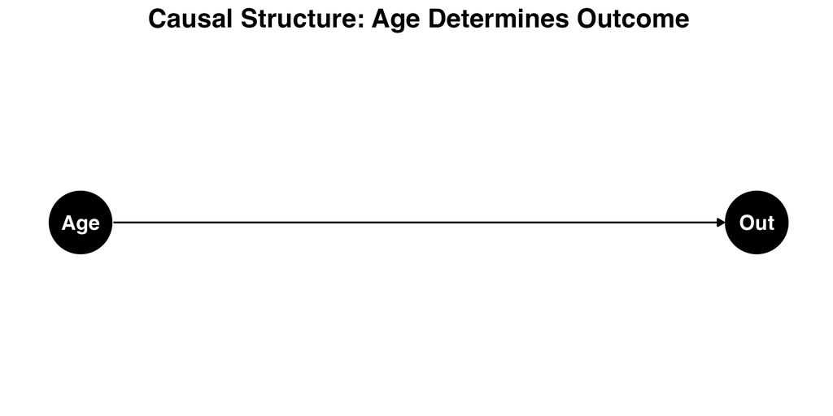

**No confounding here**. Just one cause: Age

But crude rate still depends on age.

## Simulated Dataset 1: Age Distribution

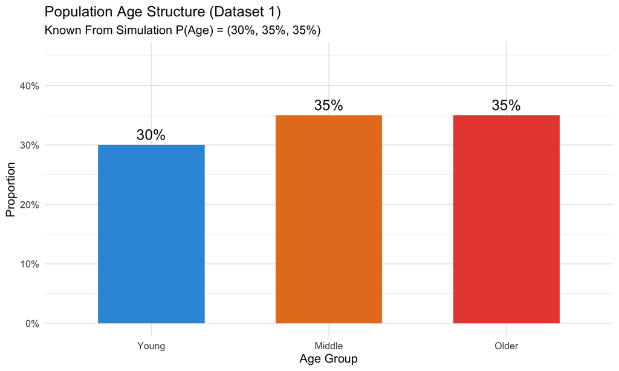

## Age-Specific Rates Of Late Presentation

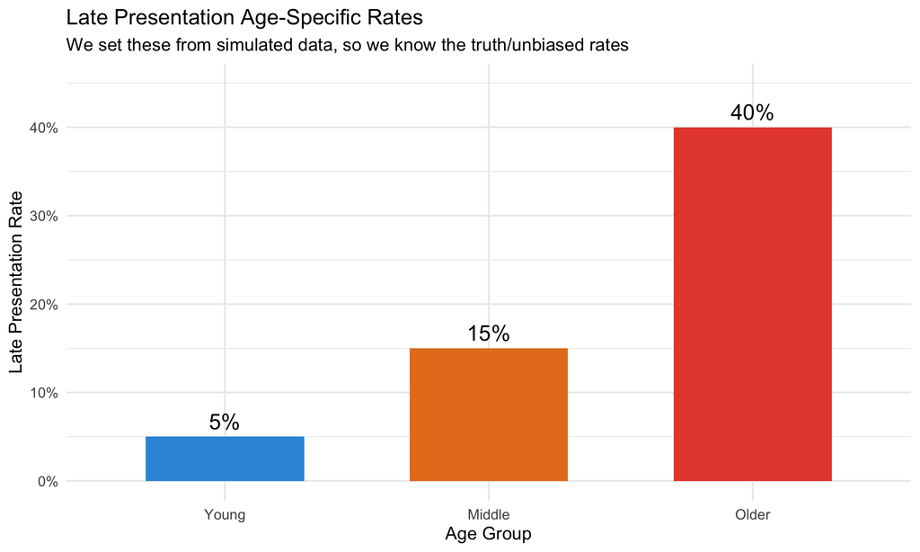

## Computing the Expected Value

$$E[Y] = \sum_{\text{age}} E[Y \mid \text{Age}] \times P(\text{Age})$$

```r
# Our age-specific rates (known truth)
rates <- c(Young = 0.05, Middle = 0.15, Older = 0.40)

# Our population weights
weights <- c(Young = 0.30, Middle = 0.35, Older = 0.35)

# Expected value
expected_rate <- sum(rates * weights)
expected_rate
```

```
[1] 0.2075
```

**Expected crude rate:** 20.7%

This is what we should see in the data.

## Observed vs Expected

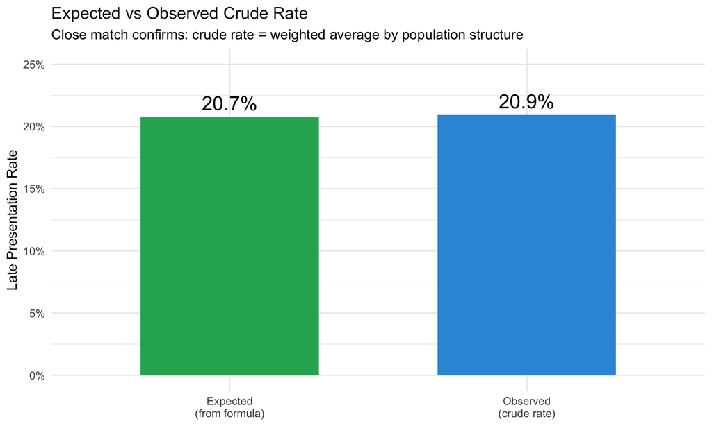

Because we don’t have confounding here, our actual rate matches our expected rate.

## What If We Had a Different Population?

- Imagine Population A: Mostly young people → low crude rate
- Imagine Population B: Mostly older people → high crude rate
- **Same age-specific rates** (5%, 15%, 40%)
- **Different crude rates** because populations differ

## Why Standardization Matters

To compare populations fairly, we need:

- Apply age-specific rates to a **standard population**
- Use the **same age weights** for both groups
- Remove the effect of different population structures

# Example 2: Age + Gender

## Adding Gender: Simpson’s Paradox

**Research question:** Do men or women have higher late-presentation rates?

## What We Know

- Now we have Gender and Age in our data
- **Known truth** (from simulation):
  - Men have higher risk within **every** age group
  - Women live longer → more older women

**Question:** What will crude rates show?

## Causal Structure: Age + Gender → Outcome

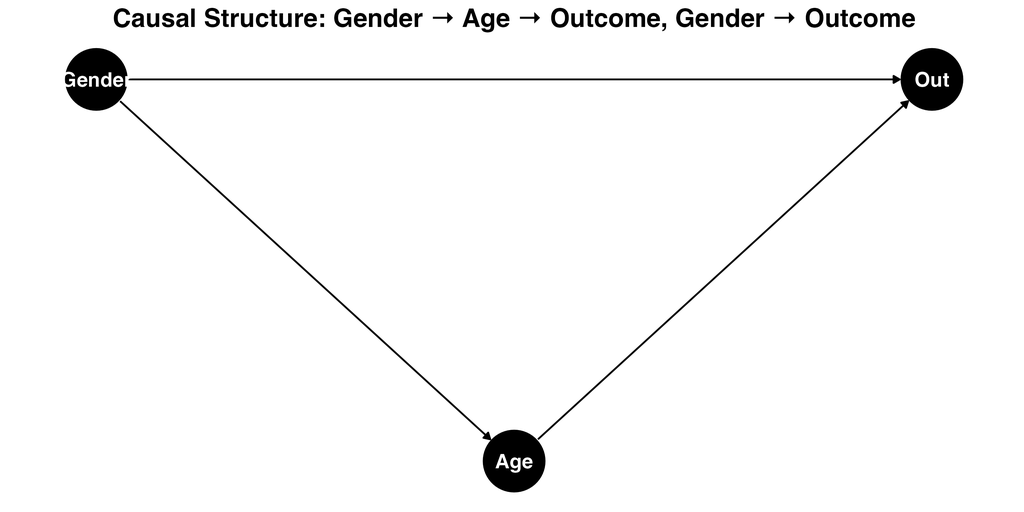

## Confounding By Age

**This is confounding!**

Gender affects Age (women live longer), and Age affects Outcome.

Crude comparison of men vs women is **biased** by age composition.

## Simulated Dataset 2: Age Structure by Gender

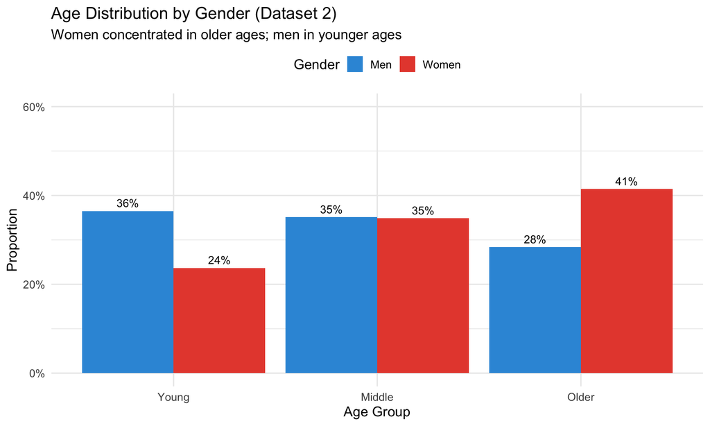

**Key:** P(Age | Man) ≠ P(Age | Woman), but **marginal (overall) P(Age) same as Dataset 1**

## Crude Rates by Gender

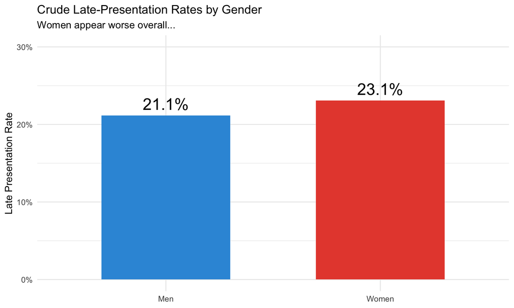

**Observation:** Women have higher crude rate

**But is this the truth?**

## Age-Specific Rates by Gender

```r
age_gender_rates <- sim2_data |>
  group_by(gender, age_group) |>
  summarise(rate = mean(late_presentation), .groups = "drop")

age_gender_rates
```

```
# A tibble: 6 × 3
  gender age_group   rate
  <chr>  <fct>      <dbl>
1 Men    Young     0.0633
2 Men    Middle    0.162
3 Men    Older     0.462
4 Women  Young     0.0508
5 Women  Middle    0.153
6 Women  Older     0.399
```

**Within every age group, men have higher rates!**

This is **Simpson’s Paradox**.

## Visualizing Simpson’s Paradox

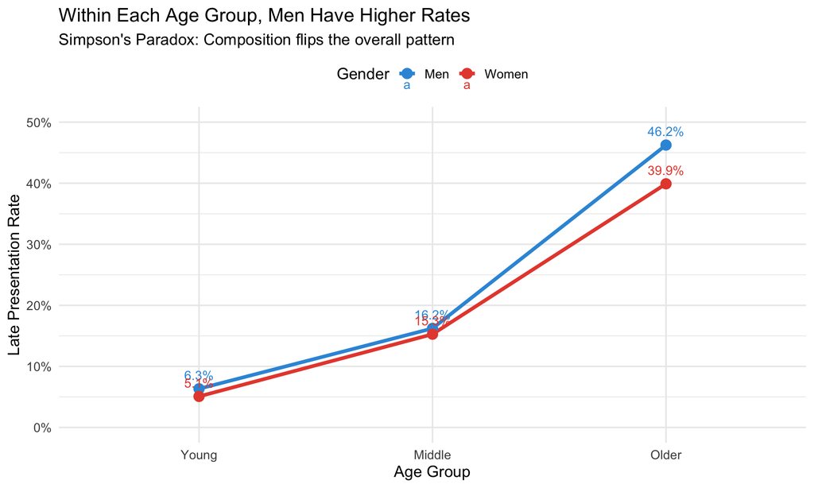

## What Went Wrong?

Remember the expectation formula:

$$E[Y \mid \text{Gender}] = \sum_{\text{age}} E[Y \mid \text{Gender}, \text{Age}] \times P(\text{Age} \mid \text{Gender})$$

## The Problem

- $P(\text{Age} \mid \text{Man})$ ≠ $P(\text{Age} \mid \text{Woman})$
- Women concentrated in **older ages** (high risk)
- Men concentrated in **younger ages** (low risk)

## Why It Flips

- Men have higher risk within **every** age group
- But **different age weights** flip the crude pattern
- This is confounding in action

## Indirect Standardization: The Goal

**Estimate what each group’s outcomes *should look like*** if they experienced the **same rates as a reference population**

## The Method

- Start with **known rates** from a large or “standard” population (for example, national age-specific rates)
- Apply those rates to your **study population’s structure** (how many people you have in each age group)
- This gives you the **expected number of events** *if your group had the same risks as the reference group*

## Interpreting the Results

- Compare **observed vs expected** events → this ratio is the **Standardized Mortality (or Morbidity) Ratio (SMR)**
- SMR = 1 → outcomes match the reference population
- SMR > 1 → more events than expected
- SMR < 1 → fewer events than expected

## Why “Indirect”?

We don’t re-calculate each group’s own rates

- We *borrow* the standard rates and apply them to our data
- Then compare what we **saw** to what we **would expect**

## Step 1: Define Our “Ingredients”

```r
# Calculate observed rates in our data
age_gender_rates <- sim2_data |>
  group_by(gender, age_group) |>
  summarise(rate = mean(late_presentation), .groups = "drop")

# Define standard rates (e.g., from national statistics)
standard_rates <- data.frame(
  age_group = factor(c("Young", "Middle", "Older"),
                    levels = c("Young", "Middle", "Older")),
  std_rate = c(0.04, 0.14, 0.42)  # Externally-determined rates; they differ a little
)

# Get population counts by gender and age
pop_counts <- sim2_data |>
  group_by(gender, age_group) |>
  summarise(n = n(), .groups = "drop")
```

## Step 2: Calculate SMR for Each Group

```r
# For each gender, calculate observed and expected events
indirect_std <- pop_counts |>
  left_join(standard_rates, by = "age_group") |>  # Merge in our rates
  left_join(age_gender_rates, by = c("gender", "age_group")) |>
  group_by(gender) |>
  summarise(
    observed = sum(n * rate),        # Actual events in our data
    expected = sum(n * std_rate),    # Expected if standard rates applied
    SMR = observed / expected
  )
```

## The Results

```r
indirect_std
```

```
# A tibble: 2 × 4
  gender observed expected   SMR
  <chr>     <dbl>    <dbl> <dbl>
1 Men       2085.    1805. 1.16
2 Women     2338     2355. 0.993
```

## SMR: Standardized Morbidity Ratio

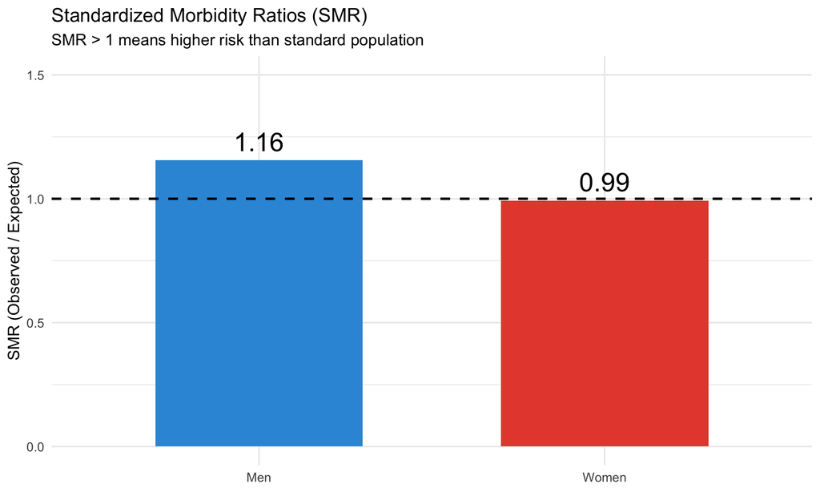

**Interpretation:** Men have 16% higher risk than expected from standard rates

## Direct Standardization: The Goal

**What would rates be if men and women had the same age distribution?**

```r
# Calculate observed rates in our data
age_gender_rates <- sim2_data |>
  group_by(gender, age_group) |>
  summarise(rate = mean(late_presentation), .groups = "drop")

# Use marginal P(Age) as standard weights
std_weights <- sim2_data |>
  count(age_group) |>
  mutate(weight = n / sum(n))
```

## Calculate Standardized Rates

```r
# Apply standard weights to gender-age specific rates
direct_std <- age_gender_rates |>
  left_join(std_weights, by = "age_group") |>
  group_by(gender) |>
  summarise(standardized_rate = sum(rate * weight))

direct_std
```

```
# A tibble: 2 × 2
  gender standardized_rate
  <chr>              <dbl>
1 Men                0.238
2 Women              0.208
```

## Crude vs Standardized Rates

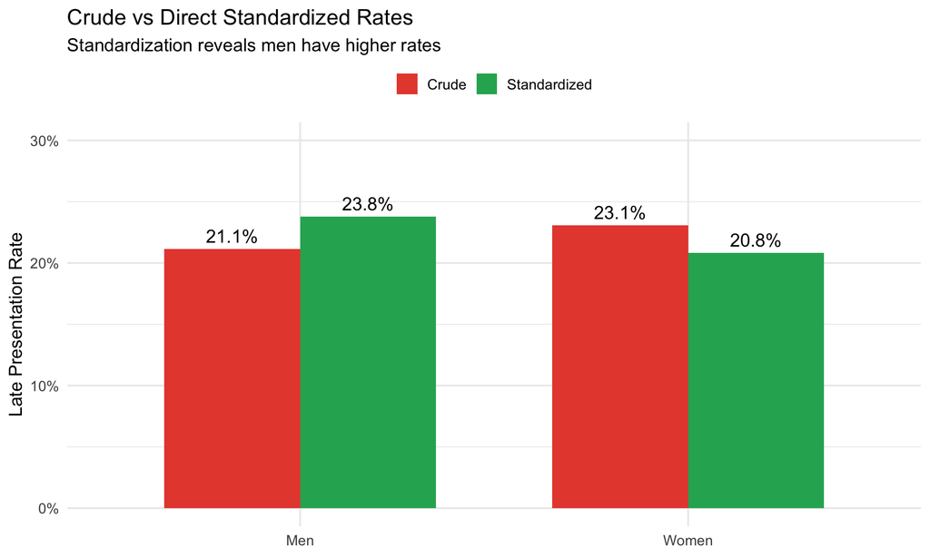

**Pattern reverses!** Standardization reveals the truth: men have higher risk.

## Key Insight: Confounding

- **Crude rates get it wrong** because Gender → Age and Age → Outcome
- **Age is a confounder** of the Gender-Outcome relationship
- **Direct standardization** fixes $P(\text{Age})$ to break the confounding

## The Result

Direct standardization gives us the **correct comparison of gender differences**

**Next:** What happens when we have multiple confounders?

# Example 3: Age + Gender + GOC

## Adding Gender Opportunity Context

**Research question:** Same question, but now we also have GOC data

GOC = Gender Opportunity Context (gendered norms/power/access)

## Known Truth from Simulation

- Age effect: Young=5%, Middle=15%, Older=40%
- Gender effect: Men higher within age groups
- GOC effect: Low/Mid higher than High

## Multiple Confounding Pathways

- GOC → Age (low GOC = younger; more constraints/shorter healthy lifespan)
- GOC → Outcome (low GOC = higher risk; barriers to access/norms)
- Gender → Age (women live longer)
- Age → Outcome
- Gender → Outcome

## The Complexity

**All three variables affect both each other AND the outcome**

## Causal Structure: Multiple Confounders

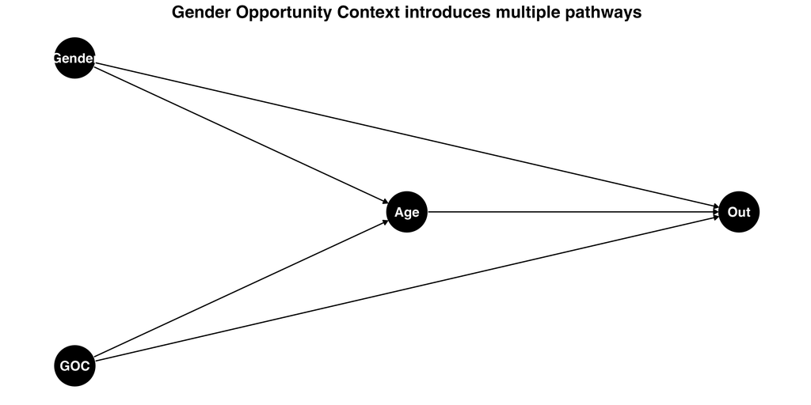

**This is complex!**

To compare groups fairly, we need to adjust for Age AND GOC.

Manual standardization becomes unmanageable.

## Simulated Dataset 3: Age by Gender and GOC

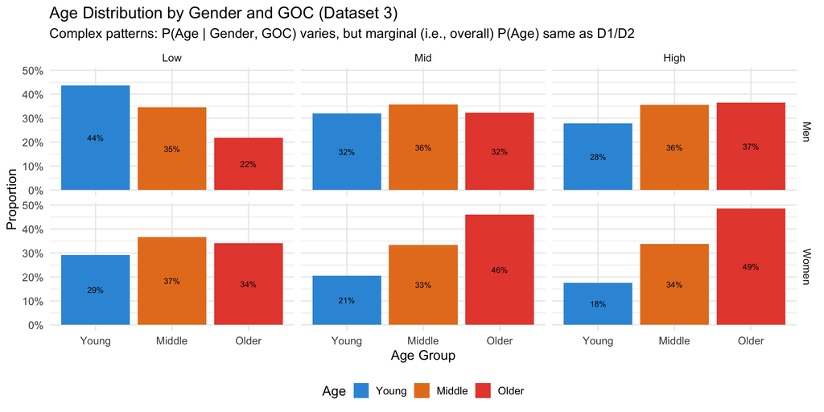

## Crude Rates by Gender

```r
# By Gender
sim3_data |>
  group_by(gender) |>
  summarise(crude_rate = mean(late_presentation))
```

```
# A tibble: 2 × 2
  gender crude_rate
  <chr>       <dbl>
1 Men         0.244
2 Women       0.258
```

## Crude Rates by GOC

```r
# By GOC
sim3_data |>
  group_by(goc) |>
  summarise(crude_rate = mean(late_presentation))
```

```
# A tibble: 3 × 2
  goc   crude_rate
  <fct>      <dbl>
1 Low        0.247
2 Mid        0.258
3 High       0.248
```

**All confounded!** Low GOC appears to have every so slightly lower risk (wrong!) because low GOC contexts are younger.

## Why Manual Standardization Fails

To standardize by Age and GOC:

- Need age-GOC-specific rates for each gender: 3 ages × 3 GOC = **9 strata per gender**
- With small cell counts, rates become unstable
- Adding more confounders (ethnicity, region, comorbidity) → exponential growth

## The Solution

**Regression models do multivariable standardization automatically**

## Poisson Regression

```r
glm_fit <- glm(late_presentation ~ gender + age_group + goc,
               family = poisson(link = "log"),
               data = sim3_data)
```

## What the Model Does

Fits a model:
$$\begin{aligned}
\log(E[Y \mid \text{Gender}, \text{Age}, \text{GOC}]) = \\
\beta_0 + \beta_{\text{Gender}} + \beta_{\text{Age}} + \beta_{\text{GOC}}
\end{aligned}$$

## Why This Works

- Automatically adjusts for all confounders simultaneously
- **This is standardization!** Model weights by the data’s covariate distribution

## Adjusted Probabilities: Men vs Women

```r
library(emmeans)

# Get marginal probabilities by gender (adjusted for age and GOC)
emmeans(glm_fit, ~ gender, type = "response")
```

```
 gender  rate      SE  df asymp.LCL asymp.UCL
 Men    0.194 0.00466 Inf     0.185     0.204
 Women  0.167 0.00421 Inf     0.159     0.175

Results are averaged over the levels of: age_group, goc
Confidence level used: 0.95
Intervals are back-transformed from the log scale
```

## Gender Probability Differences

```r
# Probability difference
pairs(regrid(emmeans(glm_fit, ~ gender, type = "response")), reverse = TRUE)
```

```
 contrast    estimate      SE  df z.ratio p.value
 Women - Men  -0.0275 0.00514 Inf  -5.342  <.0001

Results are averaged over the levels of: age_group, goc
```

**Men have 2.8 percentage points higher risk than women** (after adjusting for age and GOC)

## Adjusted Probabilities by GOC

```r
# Get marginal probabilities by GOC (adjusted for age and gender)
emmeans(glm_fit, ~ goc, type = "response")
```

```
 goc   rate      SE  df asymp.LCL asymp.UCL
 Low  0.203 0.00491 Inf     0.194     0.213
 Mid  0.177 0.00490 Inf     0.168     0.187
 High 0.162 0.00560 Inf     0.151     0.173

Results are averaged over the levels of: gender, age_group
Confidence level used: 0.95
Intervals are back-transformed from the log scale
```

## GOC Probability Differences

```r
# Probability differences
pairs(regrid(emmeans(glm_fit, ~ goc, type = "response")), reverse = TRUE)
```

```
 contrast   estimate      SE  df z.ratio p.value
 Mid - Low   -0.0263 0.00604 Inf  -4.350  <.0001
 High - Low  -0.0417 0.00666 Inf  -6.259  <.0001
 High - Mid  -0.0154 0.00655 Inf  -2.349  0.0493

Results are averaged over the levels of: gender, age_group
P value adjustment: tukey method for comparing a family of 3 estimates
```

## Model-based Approaches

Modeling lets us extend the logic of standardization to more complex causal structures gracefully

# Summary

## Recap

1. **Example 1 (Age only):** Crude rate depends on population structure
2. **Example 2 (Age + Gender):** Confounding creates Simpson’s Paradox; direct standardization fixes it
3. **Example 3 (Age + Gender + GOC):** Multiple confounders: regression models generalize standardization

## All Methods Compared

Getting the Expected Value Right Requires Understanding Causal Structure

| Method | Example 2 (Gender) | Example 3 (GOC + Gender) |
| --- | --- | --- |
| Crude | Women appear worse (incorrect) | Low GOC appears better (incorrect) |
| Direct Standardization | Men worse (correct) | Too many strata (unmanageable) |
| Poisson GLM | Men worse (correct) | Men worse, Low GOC worse (correct) |

## Key Takeaways

1. **Expectation** = weighted average of subgroup rates
2. **Population structure** determines which weights we use
3. **Confounding** occurs when groups have different structures
4. **Standardization** uses common weights to make fair comparisons
5. **Regression models** = automated multivariable standardization

## Connecting to Policy

If we **only** looked at crude rates:

- **Example 2:** Crude data: women seem worse. Truth: men higher risk
- **Example 3:** Crude data: low-opportunity contexts seem safer. Truth: risk highest where gender equality is lowest

## The Consequences

- **Wrong interventions:** Misallocated resources, ineffective programs
- **Root cause:** Ignored causal structure and population composition

**Gendered health analysis requires understanding confounding, causal structure, and standardization**

## Summary

**What you just learned:**

- Causal structure and confounding
- Direct/indirect standardization for 1-2 confounders
- Why manual standardization fails with many confounders

# Questions?

Email me at `ewestlund@jhu.edu` and I’m happy to talk!

## Thank You

**Erik Westlund**

ewestlund@jhu.edu  
Johns Hopkins Biostatistics Center  
Johns Hopkins Bloomberg School of Public Health

Slides and code: github.com/erikwestlund/gdaw-standardization-presentation-2025